# Coursera Data Science : Machine Learning Project

Coral Peck

1 August 2017

## Summary

The goal of this project is to use data from accelerometers on the belt, forearm, arm, and dumbell of 6 participants, to predict the manner in which they did the exercise. They were asked to perform barbell lifts correctly and incorrectly in 5 different ways. More information is available from the website here: http://groupware.les.inf.puc-rio.br/har (see the section on the Weight Lifting Exercise Dataset).

## Sypnosis

We used Recursive Feature Elimination (RFE) in caret to identify 17 features, which we later fed into a Random Forest model to predict which exercise was done. The final model has approximately 99% accuracy and the details of the modelling follows below.

## Exploratory Analysis

Here, we find that there are alot of missing datapoints (NA and #!NA/0!). We do not think it is appriopriate to impute values for missing data where more than 95% are missing. We removed these predictors (with >95% missing data), as well as irrelevant predictors which are not usable for future prediction purposes (index, user_name, raw_timestamp_part_1, raw_timestamp_part_2, cvtd_timestamp, new_window, num_window). We are left with 52 potential predictors, and we saw that the data is distributed among the 5 exercises for modelling.

```r
data<-read.csv("pml-training.csv",na.strings=c("NA","#DIV/0!"))
NArate <- apply(data, 2, function(x) sum(is.na(x)))/nrow(data)
data <- data[!(NArate>0.95)]
str(data)
```

```
## 'data.frame':    19622 obs. of  60 variables:
##  $ X                   : int  1 2 3 4 5 6 7 8 9 10 ...
##  $ user_name           : Factor w/ 6 levels "adelmo","carlitos",..: 2 2 2 2 2 2 2 2 2 2 ...
##  $ raw_timestamp_part_1: int  1323084231 1323084231 1323084231 1323084232 1323084232 1323084232 1323084232 1323084232 1323084232 1323084232 ...
##  $ raw_timestamp_part_2: int  788290 808298 820366 120339 196328 304277 368296 440390 484323 484434 ...
##  $ cvtd_timestamp      : Factor w/ 20 levels "02/12/2011 13:32",..: 9 9 9 9 9 9 9 9 9 9 ...
##  $ new_window          : Factor w/ 2 levels "no","yes": 1 1 1 1 1 1 1 1 1 1 ...
##  $ num_window          : int  11 11 11 12 12 12 12 12 12 12 ...
##  $ roll_belt           : num  1.41 1.41 1.42 1.48 1.48 1.45 1.42 1.42 1.43 1.45 ...
##  $ pitch_belt          : num  8.07 8.07 8.07 8.05 8.07 8.06 8.09 8.13 8.16 8.17 ...
##  $ yaw_belt            : num  -94.4 -94.4 -94.4 -94.4 -94.4 -94.4 -94.4 -94.4 -94.4 -94.4 ...
##  $ total_accel_belt    : int  3 3 3 3 3 3 3 3 3 3 ...
##  $ gyros_belt_x        : num  0 0.02 0 0.02 0.02 0.02 0.02 0.02 0.02 0.03 ...
##  $ gyros_belt_y        : num  0 0 0 0 0.02 0 0 0 0 0 ...
##  $ gyros_belt_z        : num  -0.02 -0.02 -0.02 -0.03 -0.02 -0.02 -0.02 -0.02 -0.02 0 ...
```

[output cut: 46 more lines]

```r
table(data$classe)
```

```
##
##    A    B    C    D    E
## 5580 3797 3422 3216 3607
```

## Feature Selection

We now do feature selection to identify and remove redundant attributes from 52 predictors. We do this by using the Recursive Feature Elimination (RFE) in caret to identify the optimal number of features.

We hit 2 issues here :

*1) Long computational times of a few hours with repeated k-fold cross validation and multiple subsets*

To check that the model accuracy will not be too adversely affected, We split the training data into 2. 70% of the training data will be used for predictor selection and model fitting; remaining 30% will be used for performance evaluation.

*2) The model selected by RFE is based on maximising “Accuracy”. However the differences in accuracy between 17 and 52 features (model with highest accuracy) is less than 1 percent.*

Given the small difference in model accuracy, it is likely that the differences are due to randomness in the data and using all 52 parameters increases the model complexity without giving real benefits in accuracy. Hence we decided to use 17 features model for model training and validation instead of that chosen by inital model.

```r
#loading libraries
library(caret)
library(mlbench)
library(Hmisc)
library(randomForest)
library(parallel)
library(doParallel)

#Setup parallel processing; convention to leave 1 core for OS
cluster <- makeCluster(detectCores() - 1)
registerDoParallel(cluster)

# Splitting the data into training and validating sets
set.seed(168)
index <- createDataPartition(y=data$classe,p=.70,list=F)
training <- data[index,]
validating <- data[-index,]
xrfe<-training[,8:59]
yrfe<-training[,60]

#Setup parameters for RFE process
rfectrl <- rfeControl(functions = rfFuncs,
                   method = "cv",
                   number = 5,
                   verbose = FALSE,
                   returnResamp = "all",
                   allowParallel = TRUE)
subsets <- c(10, 15, 16, 17, 18, 19, 20,30,40)
set.seed(10)
rfeProfile <- rfe(xrfe, yrfe, sizes = subsets, rfeControl = rfectrl)
rfeProfile
```

```
##
## Recursive feature selection
##
## Outer resampling method: Cross-Validated (5 fold)
##
## Resampling performance over subset size:
##
##  Variables Accuracy  Kappa AccuracySD  KappaSD Selected
##         10   0.9841 0.9799   0.003766 0.004765
##         15   0.9881 0.9849   0.001769 0.002239
##         16   0.9884 0.9853   0.001384 0.001751
##         17   0.9892 0.9863   0.001732 0.002191
##         18   0.9910 0.9887   0.001250 0.001582
##         19   0.9911 0.9888   0.001166 0.001475
##         20   0.9902 0.9877   0.002638 0.003338
##         30   0.9921 0.9901   0.001577 0.001995
##         40   0.9932 0.9913   0.001633 0.002067
##         52   0.9932 0.9914   0.001658 0.002098        *
##
## The top 5 variables (out of 52):
##    roll_belt, magnet_dumbbell_z, yaw_belt, magnet_dumbbell_y, pitch_belt
```

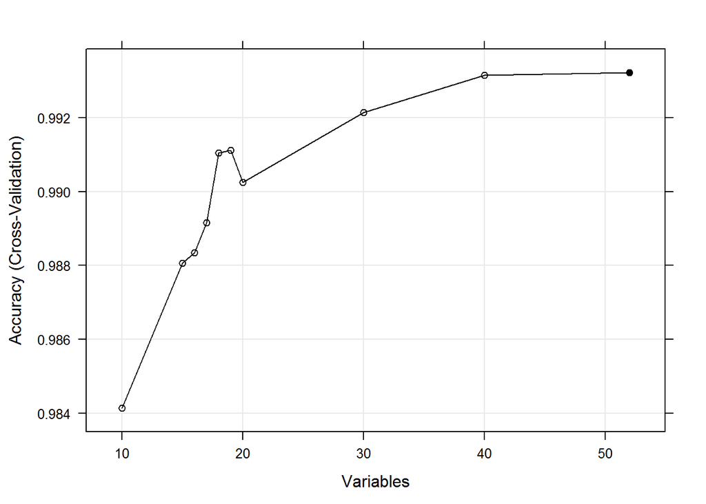

```r
# plot of how model accuracy changes with number of features used in model
trellis.par.set(caretTheme())
plot1 <- plot(rfeProfile, type = c("g", "o"))
print(plot1)
```

```r
# Update the model to use 17 features
modeltrained<-update(rfeProfile,x=xrfe,y=yrfe,size=17)

# Training Accuracy
modeltrained$fit
```

```
##
## Call:
##  randomForest(x = x, y = y, importance = first)
##                Type of random forest: classification
##                      Number of trees: 500
## No. of variables tried at each split: 4
##
##         OOB estimate of  error rate: 0.81%
## Confusion matrix:
##      A    B    C    D    E class.error
## A 3901    3    0    1    1 0.001280082
## B   15 2620   22    1    0 0.014296464
## C    0   17 2368   11    0 0.011686144
## D    0    0   25 2224    3 0.012433393
## E    0    0    3    9 2513 0.004752475
```

From the plot above, we see that the model with best accuracy chosen by RFE is one with 52 features at >99.3%. However, we also see that we can reach 99% accuracy with just 17 features. We decided to proceed with just 17 features so as to NOT complicate the model without commensurate benefits in model accuracy.

Since we did not use the “optimal” model computed by RFE in the first run, we needed to update RFE to run again with 17 features for prediction purposes. We saw that the model accuracy using training data is still approx 99% after updating the model. OOB estimate of error rate: 0.81%

## Model Validation

Here we are using the 30% training data set to assess model accuracy. We see that the model accuracy remains approx 99%.

```r
# Preparing the data for validation so that it has the same number of features as the model used for training
xvalidate<-validating[,predictors(modeltrained$fit)]
yvalidate<-validating[,"classe"]

# Predicting Classe using modeltrained and assessing model accuracy
predictvalidate<-predict(modeltrained$fit,newdata=xvalidate)
confusionMatrix(predictvalidate,yvalidate)
```

```
## Confusion Matrix and Statistics
##
##           Reference
## Prediction    A    B    C    D    E
##          A 1668    4    0    0    0
##          B    6 1123    5    2    1
##          C    0   11 1016    3    1
##          D    0    1    5  956    0
##          E    0    0    0    3 1080
##
## Overall Statistics
##
##                Accuracy : 0.9929
##                  95% CI : (0.9904, 0.9949)
##     No Information Rate : 0.2845
##     P-Value [Acc > NIR] : < 2.2e-16
##
##                   Kappa : 0.991
##  Mcnemar's Test P-Value : NA
##
## Statistics by Class:
##
##                      Class: A Class: B Class: C Class: D Class: E
## Sensitivity            0.9964   0.9860   0.9903   0.9917   0.9982
## Specificity            0.9991   0.9971   0.9969   0.9988   0.9994
## Pos Pred Value         0.9976   0.9877   0.9855   0.9938   0.9972
## Neg Pred Value         0.9986   0.9966   0.9979   0.9984   0.9996
## Prevalence             0.2845   0.1935   0.1743   0.1638   0.1839
## Detection Rate         0.2834   0.1908   0.1726   0.1624   0.1835
## Detection Prevalence   0.2841   0.1932   0.1752   0.1635   0.1840
## Balanced Accuracy      0.9977   0.9915   0.9936   0.9952   0.9988
```

```r
stopCluster(cluster)
registerDoSEQ()
```